# New Tables: Industry level

- Faire les tableaux suivants:
  - Tableau 4: Kuznet: benchmark → Revision
    - Trouver un tableau avec les déciles pour montrer:
      - turning point croissant pour des villes avec une dominance étatique de plus en plus large
    - Regarder si gdp/cap prix constant
    - Indiquer les turning points dans les tableaux
- Partie 6:
  - Tableau 8:
    - estimer 2 modèles sur des échantillons differents
      - modèle 1 → TCZ *Polluted* Period
      - modèle 2 → Target *polluted*Period
    - Echantillonnage → prendre soit industry soit city industry
      - Big
        - Via Herfhindal
          - benchmark →Revision
      - Foreign
        - via output/capital/employment
      - SOEs
        - via output/capital/employment
      - SPZ
      - Coastal
    - Chaque tableau avec Panel A pour supérieur threshold, Panel B pour inférieur threshold
  - Tableau 9:
    - Enlever SPZ & Coastal
    - estimer 2 modèles sur des échantillons differents
      - modèle 1 → TCZ *Polluted* Period
      - modèle 2 → Target *polluted*Period
    - Idem tableau 8

```
Service account storage and Bigquery are now connected.
Service account storage is stored as <google.cloud.storage.client.Client object at 0xa16aa0c10> and accessible with "Storage_account"
Service account Bigquery is stored as <google.cloud.bigquery.client.Client object at 0xa16aa0d10> and accessible with "bigquery_account"
```

|  | year | Period | Province_en | Lower_location | Larger_location | Coastal | cityen | geocode4_corr | TCZ_c | target_c | effort_c | industry | ind2 | Short | output_fcit | capital_fcit | labour_fcit | out_share_SOE | cap_share_SOE | lab_share_SOE | tso2_cit | tso2_i | tCOD_cit | twaste_water_cit | polluted_di | polluted_mi | polluted_thre | FE_c_i | FE_t_i | … |
| --- | --- | --- | --- | --- | --- | --- | --- | --- | --- | --- | --- | --- | --- | --- | --- | --- | --- | --- | --- | --- | --- | --- | --- | --- | --- | --- | --- | --- | --- | --- |
| 0 | 2002 | Before | Shanxi | Central | Central | False | Yuncheng | 1408 | TCZ | 0.485030 | Above | 3329 | 33 | Smelting Non-ferrous Metals | 0.000687 | 0.000293 | 0.00036 | 0.027567 | 0.221018 | 0.113467 | 24500 | 168934.454545 | 0.0 | 500 | Above | Below | Above | 11104 | 1573 | … |
| 1 | 2006 | After | Hunan | Central | Central | False | Xiangtan | 4303 | TCZ | 0.092754 | Below | 3329 | 33 | Smelting Non-ferrous Metals | 0.000950 | 0.000148 | 0.00023 | 0.027567 | 0.221018 | 0.113467 | 2304 | 168934.454545 | 0.0 | 300 | Above | Below | Above | 11105 | 1574 | … |
| 2 | 2007 | After | Hunan | Central | Central | False | Xiangtan | 4303 | TCZ | 0.092754 | Below | 3329 | 33 | Smelting Non-ferrous Metals | 0.001715 | 0.000365 | 0.00023 | 0.027567 | 0.221018 | 0.113467 | 2304 | 168934.454545 | 0.0 | 240 | Above | Below | Above | 11105 | 1572 | … |
| 3 | 2007 | After | Liaoning | Northeast | Eastern | True | Jinzhou | 2107 | TCZ | 0.080512 | Below | 3329 | 33 | Smelting Non-ferrous Metals | 0.007730 | 0.001296 | 0.00089 | 0.027567 | 0.221018 | 0.113467 | 3200 | 168934.454545 | 0.0 | 0 | Above | Below | Above | 11103 | 1572 | … |
| 4 | 2002 | Before | Liaoning | Northeast | Eastern | True | Shenyang | 2101 | TCZ | 0.230076 | Above | 3329 | 33 | Smelting Non-ferrous Metals | 0.000997 | 0.000052 | 0.00135 | 0.027567 | 0.221018 | 0.113467 | 3840 | 168934.454545 | 0.0 | 3500 | Above | Below | Above | 11106 | 1573 | … |

```
 Hlavac, Marek (2018). stargazer: Well-Formatted Regression and Summary Statistics Tables.

 R package version 5.2.2. https://CRAN.R-project.org/package=stargazer
```

A data.frame: 6 × 30

|  | year <dbl> | Period <fct> | Province_en <fct> | Lower_location <fct> | Larger_location <fct> | Coastal <lgl> | cityen <fct> | geocode4_corr <dbl> | TCZ_c <fct> | target_c <dbl> | ⋯ | tso2_cit <dbl> | tso2_i <dbl> | tCOD_cit <dbl> | twaste_water_cit <dbl> | polluted_di <fct> | polluted_mi <fct> | polluted_thre <fct> | FE_c_i <fct> | FE_t_i <fct> | FE_t_c <fct> |
| --- | --- | --- | --- | --- | --- | --- | --- | --- | --- | --- | --- | --- | --- | --- | --- | --- | --- | --- | --- | --- | --- |
| 1 | 2002 | Before | Shanxi | Central | Central | FALSE | Yuncheng | 1408 | TCZ | 0.48502998 | ⋯ | 24500 | 168934.5 | 0 | 500 | Above | Below | Above | 11104 | 1573 | 889 |
| 2 | 2006 | After | Hunan | Central | Central | FALSE | Xiangtan | 4303 | TCZ | 0.09275420 | ⋯ | 2304 | 168934.5 | 0 | 300 | Above | Below | Above | 11105 | 1574 | 420 |
| 3 | 2007 | After | Hunan | Central | Central | FALSE | Xiangtan | 4303 | TCZ | 0.09275420 | ⋯ | 2304 | 168934.5 | 0 | 240 | Above | Below | Above | 11105 | 1572 | 421 |
| 4 | 2007 | After | Liaoning | Northeast | Eastern | TRUE | Jinzhou | 2107 | TCZ | 0.08051164 | ⋯ | 3200 | 168934.5 | 0 | 0 | Above | Below | Above | 11103 | 1572 | 287 |
| 5 | 2002 | Before | Liaoning | Northeast | Eastern | TRUE | Shenyang | 2101 | TCZ | 0.23007570 | ⋯ | 3840 | 168934.5 | 0 | 3500 | Above | Below | Above | 11106 | 1573 | 432 |
| 6 | 2002 | Before | Guangdong | Coastal | Eastern | TRUE | Meizhou | 4414 | No_TCZ | 0.02596999 | ⋯ | 72752 | 168934.5 | 15500 | 115000 | Above | Below | Above | 11107 | 1573 | 909 |

# Partie 6

Estimate the following models using different subsamples:

### Model A

$$ Log SO2 emission _{i k t}=\alpha\left(\text { Period } \times \text { Target }_{i} \times \text { Polluting sectors }_{k} \right)+ Kuznet +\nu_{i k}+\lambda_{i t}+\phi_{k t}+\epsilon_{i k t} $$$$ Log SO2 emission _{i k t}=\alpha\left(\text { Period } \times \text { Target }_{i} \times \text { Polluting sectors }_{k} \times \text{ Share X}_i \right)+\nu_{i k}+\lambda_{i t}+\phi_{k t}+\epsilon_{i k t} $$

- Size
  - Via Herfhindal
    - benchmark →Revision
- Foreign
  - via output/capital/employment
- SOEs
  - via output/capital/employment
- SPZ
- Coastal

## Load Data

### Load chinese_city_characteristics from Google Spreadsheet

Feel free to add description about the dataset or any usefull information.

Profiling will be available soon for this dataset

```
Service Google Drive and Docs, Sheet are now connected.
Service Google Drive is stored as <googleapiclient.discovery.Resource object at 0x125c5ba50> and accessible with "drive"
Service Google Doc is stored as <googleapiclient.discovery.Resource object at 0x125cdfd10> and accessible with "doc"
Service Google Sheet is stored as <googleapiclient.discovery.Resource object at 0x125da6d90>and accessible with "sheet"
```

```
(30248, 37)
```

### Load TCZ_list_china from Google Spreadsheet

Feel free to add description about the dataset or any usefull information.

Profiling will be available soon for this dataset

### Compute Herfhindal: proxy Size

$$ H=\sum_{i=1}^{N} s_{i}^{2} $$

where $s_i$ is the market share of industry $i$ in a city, and $N$ is the number of firms.

We proceed as follow:

- Step 1: Compute the share [output, capital, employment] by city-industry: `market_share_cit`
- Step 2: compute the sum of squared market share by industry: `Herfindahl_it`
- Step 3: Compute the average across time: `Herfindahl_i`
- Step 4: Compute the deciles of step 3: `decile_herfhindal_i`
  - Low decile implies a low concentration within sectors
  - High decile implies a high concentration within sectors

```
1     74
2     74
3     74
4     74
5     73
6     73
7     73
8     73
9     73
10    73
Name: decile_herfhindal_i, dtype: int64
```

### Compute Ownership: proxy Foreign/SOE

$$\sum output_{io}/ \sum output_i$$

- with $i$ stands for industry
- $o$ stands for ownership (Foreign vs Domestic or SOE vs private)

#### Foreign vs domestic

We proceed as follow:

- Step 1: Compute the share [output, capital, employment] by industry, ownership (Foreign/Domestic): `Share_X_io`
- Step 2: Compute dummy when share Foreign above share domestic by industry
- Step 3: Compute decile by industry-ownership
  - Note, high decile in Foreign means the industry has relatively high share of foreign output, but not in absolule value as in step 2. A decile 9 in foreign can be a decile 2 or 3 in Domestic

```
1     145
2     145
3     145
4     145
5     144
6     143
7     143
8     143
9     143
10    143
Name: rank_share_output_i, dtype: int64
```

```
Above     12
Below    722
Name: output, dtype: int64
Above     11
Below    723
Name: capital, dtype: int64
Above     10
Below    724
Name: employment, dtype: int64
```

#### SOE

We proceed as follow:

- Step 1: Compute the share [output, capital, employment] by industry, ownership (SOE/Private): `Share_X_io`
- Step 2: Compute dummy when share SOE above share Private by industry
- Step 3: Compute decile by industry-ownership
  - Note, high decile in SOE means the industry has relatively high share of SOE output, but not in absolule value as in step 2. A decile 9 in SOE can be a decile 2 or 3 in Private

```
1     147
2     147
3     146
4     146
5     146
6     146
7     146
8     145
9     145
10    145
Name: rank_share_output_i, dtype: int64
```

```
Above     54
Below    680
Name: output, dtype: int64
Above     69
Below    665
Name: capital, dtype: int64
Above     62
Below    672
Name: employment, dtype: int64
```

|  | industry | rank_share_output_i | rank_share_capital_i | rank_share_employement_i | output | capital | employment |
| --- | --- | --- | --- | --- | --- | --- | --- |
| 0 | 3956 | 1 | 1 | 1 | Below | Below | Below |
| 1 | 2424 | 1 | 1 | 1 | Below | Below | Below |
| 2 | 3081 | 1 | 1 | 1 | Below | Below | Below |
| 3 | 3954 | 1 | 1 | 1 | Below | Below | Below |
| 4 | 3423 | 1 | 1 | 1 | Below | Below | Below |

### Add to table

INFO: NumExpr defaulting to 8 threads.

```
Below    28854
Above     1394
Name: output, dtype: int64
Below    27881
Above     2367
Name: capital, dtype: int64
Below    28737
Above     1511
Name: employment, dtype: int64
```

```
Below    30240
Above        8
Name: output, dtype: int64
Below    30210
Above       38
Name: capital, dtype: int64
Below    30210
Above       38
Name: employment, dtype: int64
```

## Table 8 Model A: Panel A

### Size

FALSE

FALSE

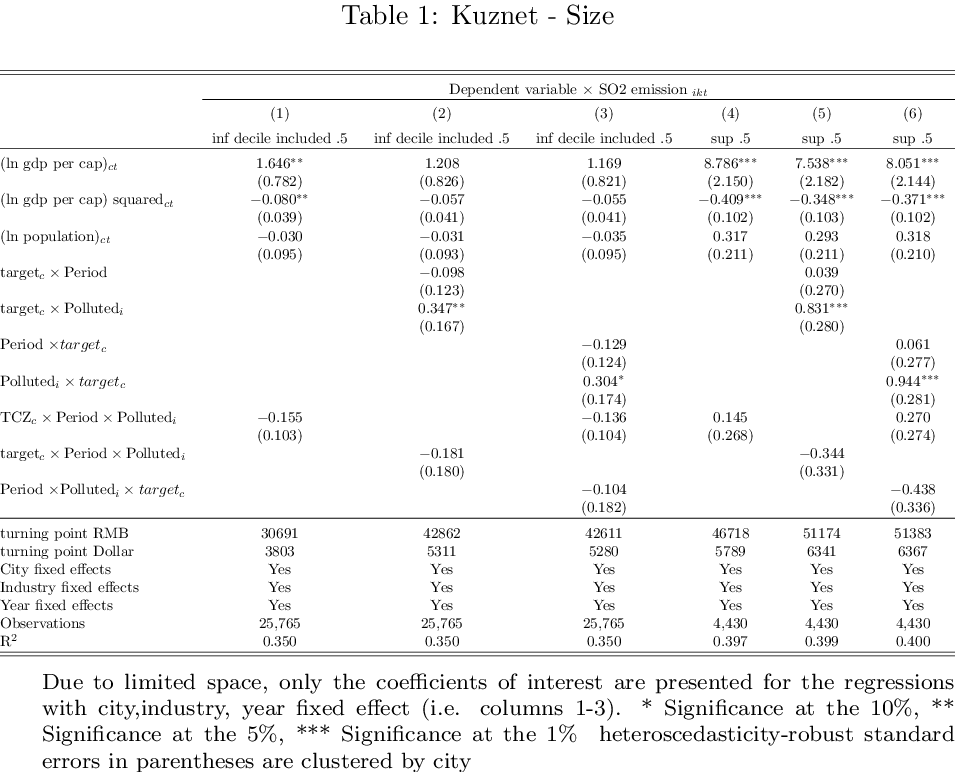

#### Foreign

FALSE

FALSE

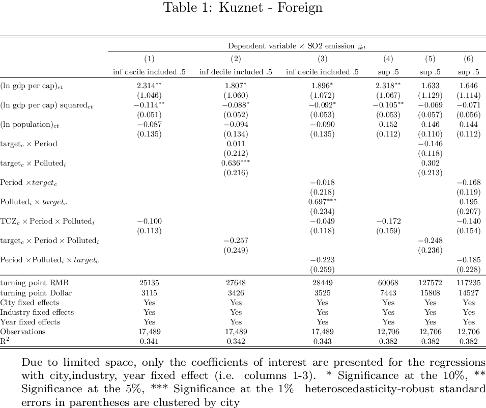

#### SOE

FALSE

FALSE

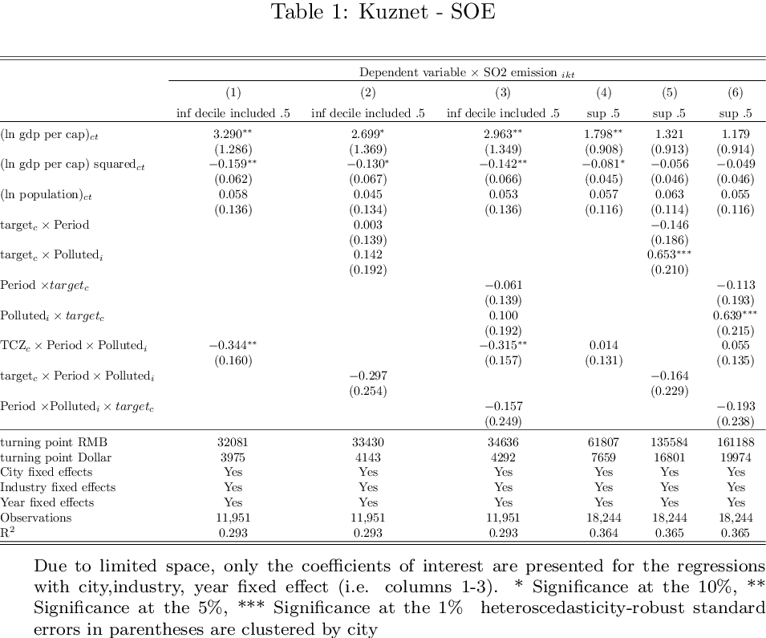

### SPZ/Coastal/TCZ

FALSE

FALSE

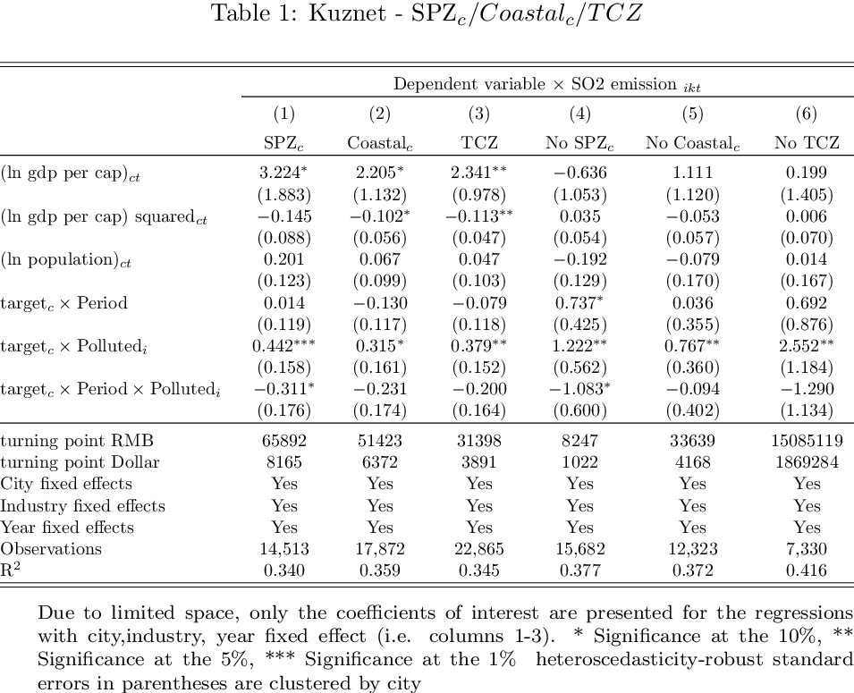

```
0
```